# Recommandation et transparence

CB

17 octobre 2019

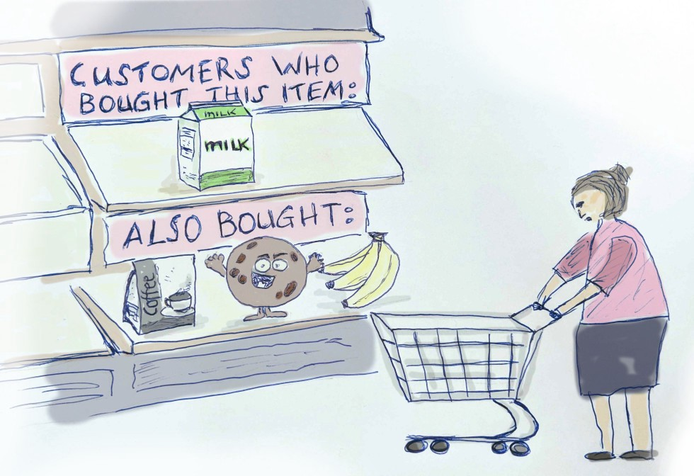

This document is writen with [rmarkdown](https://bookdown.org/yihui/rmarkdown/) and contain computations relative to a small experiment about algorithmic transparency policy. The reference paper is [available here](https://management-datascience.org/2018/01/18/satisfaction-a-legard-des-moteurs-de-recommandation-la-transparence-optimale/)

The first chunk load the package we will need and include main variable recoding.

## Elementary Statistics

We will use [ggplot2](https://ggplot2.tidyverse.org/index.html)

```r
#create concept scores for multi-items measurement

reco_a$Confiance <- (reco_a$C_Bienveillance + reco_a$C_Competence + reco_a$C_Donnees.navigation + reco_a$C_Ethique + reco_a$C_Infos.perso)/5

reco_a$Satisfaction <- (reco_a$S_Interesse.par.produits.reco+
                          reco_a$S_Promoter.score+
                          reco_a$S_Recos.repondent.aux.besoins+
                          reco_a$S_Satisfaction.globale+reco_a$S_Tentation.d.achat)/5

reco_a$Understanding <- (reco_a$U_Comment+ reco_a$U_Interets+ reco_a$U_pourquoi+ reco_a$U_Technique)/4
#basic statistic with rcmdr

numSummary(reco_a[,c("Confiance", "Satisfaction", "Understanding"), drop=FALSE], statistics=c("mean", "sd", "cv"))
```

```
##                   mean        sd        cv  n
## Confiance     3.788462 0.8264391 0.2181463 52
## Satisfaction  4.126923 0.7441577 0.1803178 52
## Understanding 4.495192 0.8945510 0.1990017 52
```

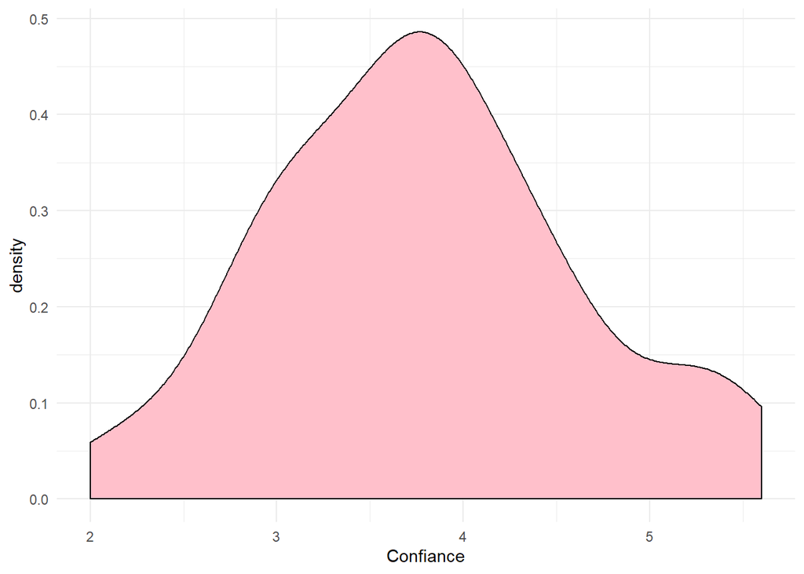

```r
#comparing empirical and theoretical distribution ( density function)

g1<-ggplot(data = reco_a, aes(x=Confiance))+geom_density(fill="pink")+theme_minimal()
g1
```

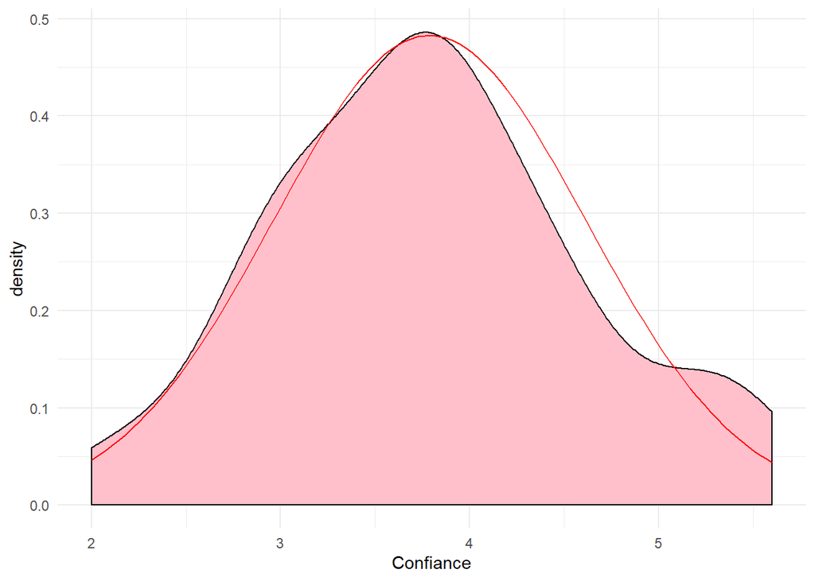

```r
g1 <- g1 + stat_function(fun=dnorm, color="red", args=list(mean=mean(reco_a$Confiance),
                                  sd=sd(reco_a$Confiance)))
g1
```

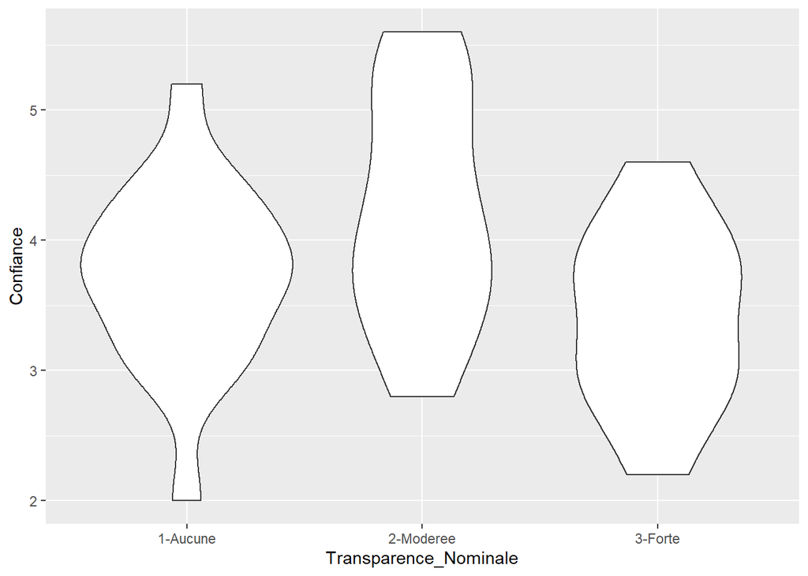

```r
#comparing distribution per group
g2<-ggplot(data = reco_a, aes(x=Transparence_Nominale,y=Confiance))+geom_violin()
g2
```

```r
Dependant<-subset(reco_a,select=c(Confiance,Satisfaction,Understanding))
Dependant<-melt(data = Dependant)
```

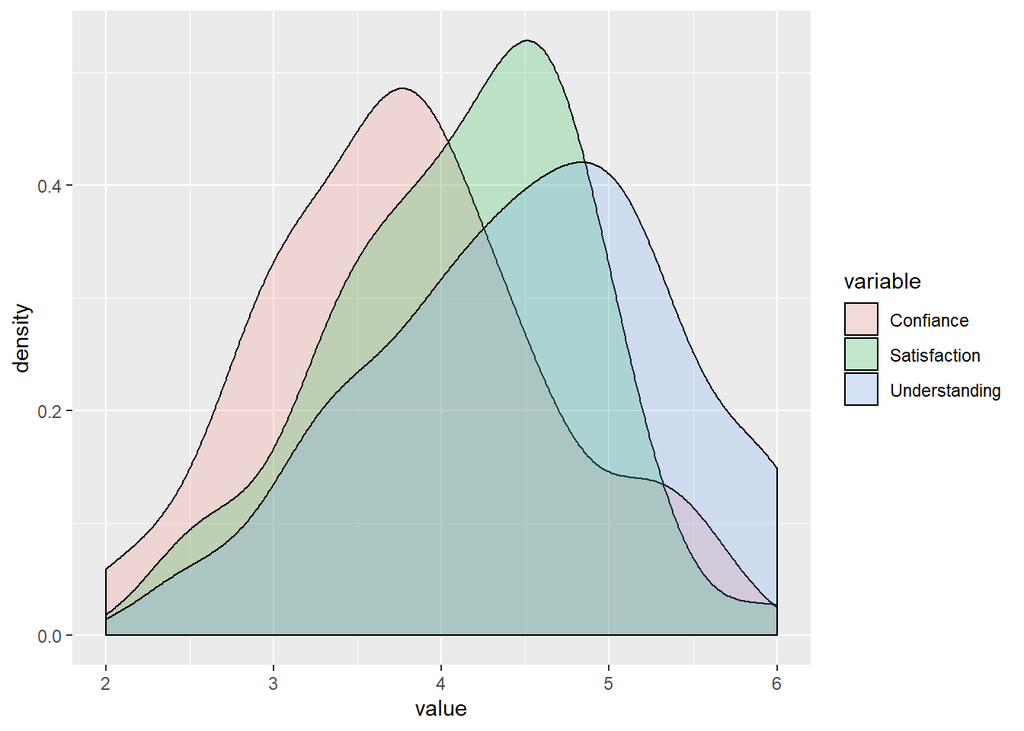

```r
ggplot(Dependant, aes(x = value, fill = variable)) + geom_density(alpha = 0.2)
```

## Analyse bivariée

### t test

the elementary bivariate analysis is a comparaison of two groups and is better if we test the difference. For a detailed presentation see https://uc-r.github.io/t_test

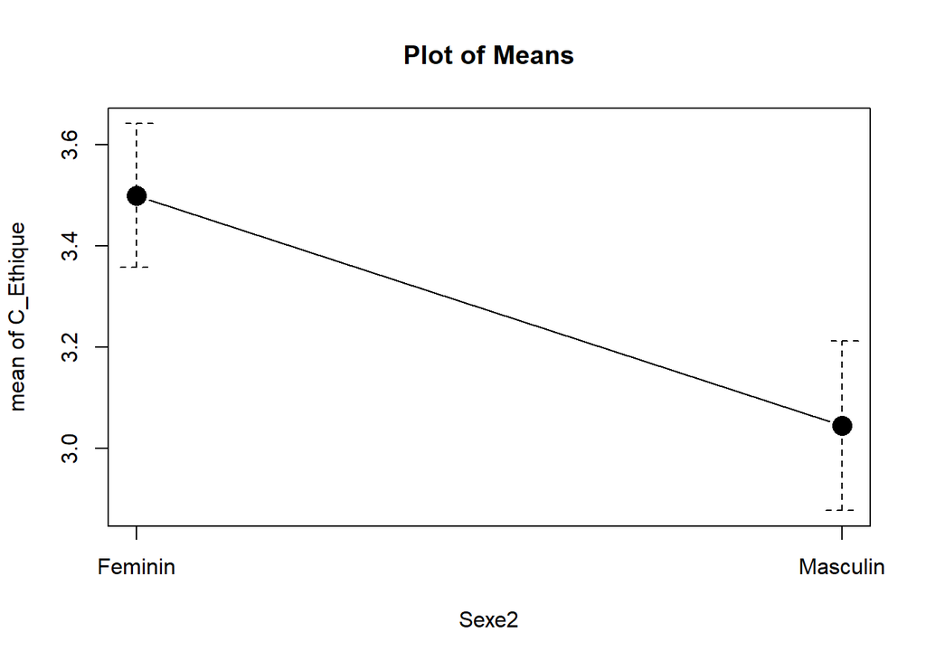

```r
reco_a$Sexe2<-as.factor(reco_a$Sexe)
with(reco_a, plotMeans(C_Ethique, Sexe2, error.bars="se", connect=TRUE)) #with Rcmdr
```

```r
t.test(C_Ethique~Sexe, alternative='two.sided', conf.level=.95, var.equal=FALSE, data=reco_a)
```

```
##
##  Welch Two Sample t-test
##
## data:  C_Ethique by Sexe
## t = 2.0714, df = 45.122, p-value = 0.04407
## alternative hypothesis: true difference in means is not equal to 0
## 95 percent confidence interval:
##  0.0125981 0.8964928
## sample estimates:
##  mean in group Feminin mean in group Masculin
##               3.500000               3.045455
```

### ANOVA

ANOVA is a kind of generalization of the 2-group comparisons

for details : https://bioinformatics-core-shared-training.github.io/linear-models-r/ANOVA.html

```r
AnovaModel.1 <- aov(Satisfaction ~ Transparence_Nominale, data=reco_a)
summary(AnovaModel.1)
```

```
##                       Df Sum Sq Mean Sq F value Pr(>F)
## Transparence_Nominale  2  4.302  2.1512   4.403 0.0174 *
## Residuals             49 23.940  0.4886
## ---
## Signif. codes:  0 '***' 0.001 '**' 0.01 '*' 0.05 '.' 0.1 ' ' 1
```

```r
with(reco_a, numSummary(Satisfaction, groups=Transparence_Nominale,
  statistics=c("mean", "sd")))
```

```
##               mean        sd data:n
## 1-Aucune  4.047059 0.4718549     17
## 2-Moderee 4.500000 0.7798944     18
## 3-Forte   3.811765 0.7920561     17
```

from http://www.sthda.com/french/wiki/ggplot2-barres-d-erreur-guide-de-demarrage-rapide-logiciel-r-et-visualisation-de-donnees

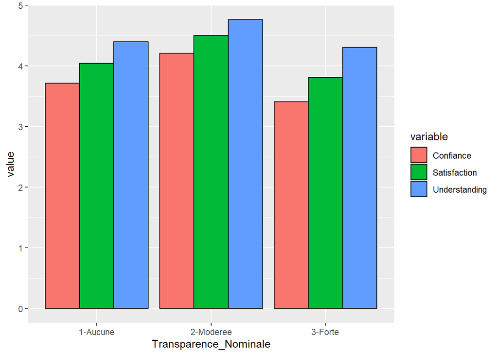

```r
#preparing the data
means<- aggregate(cbind(Confiance, Satisfaction, Understanding) ~ Transparence_Nominale, data=reco_a, FUN="mean")

Sd<- aggregate(cbind(Confiance, Satisfaction, Understanding) ~ Transparence_Nominale, data=reco_a, FUN="sd")
meansM <- melt(means, id=c("Transparence_Nominale"))
SdM <- melt(Sd, id=c("Transparence_Nominale"))
SdM$sd<-SdM$value
SdM<-subset(SdM,select=c(sd))
meansM<-cbind(meansM,SdM)

#making the chart

g<- ggplot(meansM, aes(x=Transparence_Nominale, y=value, fill=variable))
g<-g+geom_bar(stat="identity", color="black", position=position_dodge())
g
```

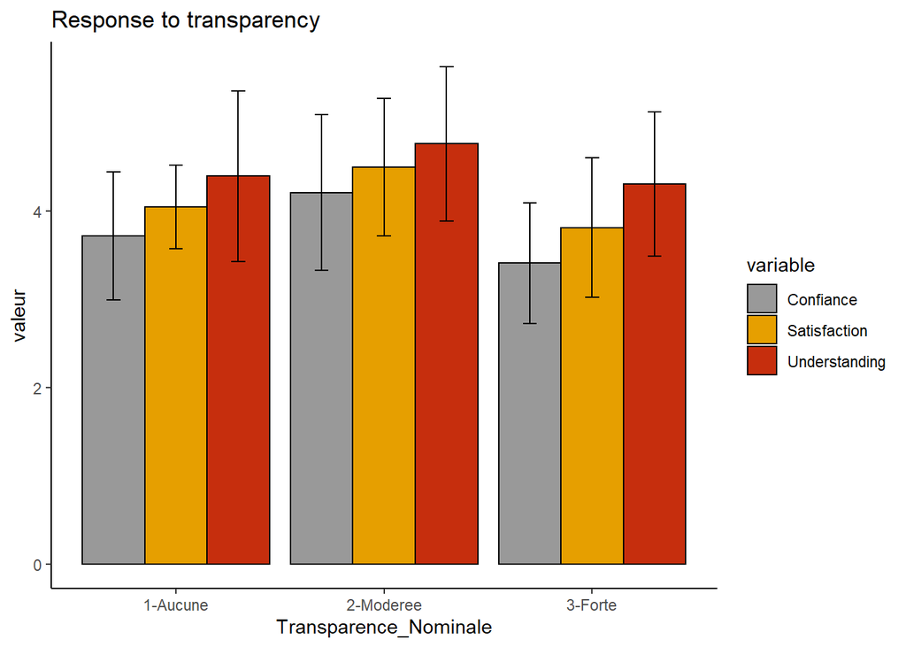

```r
g<-g+geom_errorbar(aes(ymin=value-sd, ymax=value+sd), width=.2,
                position=position_dodge(.9)) + labs(title="Response to transparency",x="Transparence_Nominale", y = "valeur")+ theme_classic() +  scale_fill_manual(values=c('#999999','#E69F00', '#c62e0d'))

g
```

### Correlations

for a definition of correlation see : http://www.r-tutor.com/elementary-statistics/numerical-measures/correlation-coefficient

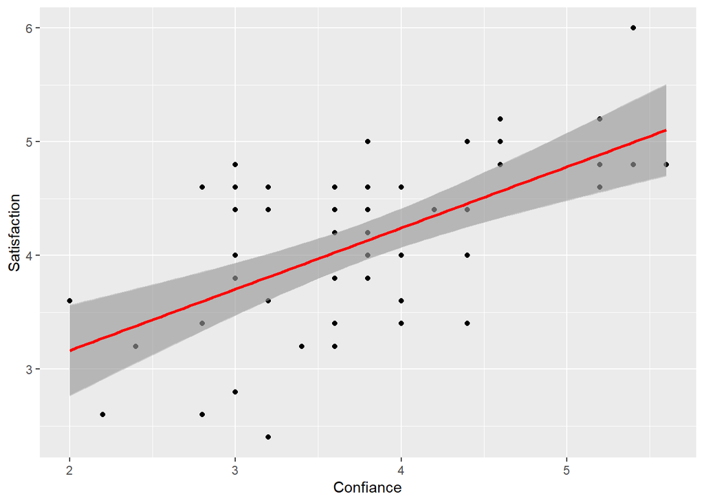

```r
ggplot(reco_a, aes(x=Confiance, y=Satisfaction)) + geom_point()+ geom_smooth(method='lm')+geom_smooth(method='gam',color="red")
```

```r
M<-cor(reco_a[,c("Confiance","Satisfaction","Understanding")], use="complete")
M
```

```
##               Confiance Satisfaction Understanding
## Confiance     1.0000000    0.5979953     0.7107255
## Satisfaction  0.5979953    1.0000000     0.4339238
## Understanding 0.7107255    0.4339238     1.0000000
```

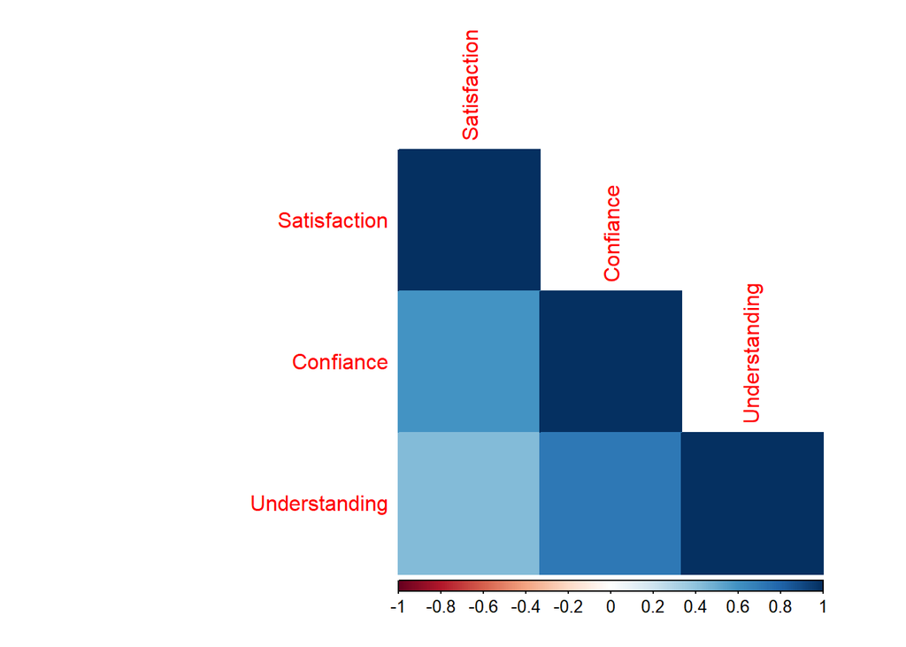

```r
corrplot(M, method="color",type="lower", order="hclust")
```

When we need to compute a large number of correlation, it is usefull to visualize the large matrix. In this case line and column are rearranged with the clustering function “hclust”.

read also https://rstudio-pubs-static.s3.amazonaws.com/240657_5157ff98e8204c358b2118fa69162e18.html

```r
Mcorr <- subset(reco_a, select=c(C_Bienveillance, C_Competence, C_Donnees.navigation, C_Ethique,  C_Infos.perso, C_Securite, S_Interesse.par.produits.reco, S_Promoter.score,S_Recos.repondent.aux.besoins, S_Satisfaction.globale, S_Tentation.d.achat,  Transparence_Numerique, U_Comment, U_Interets,U_pourquoi,U_Technique))
M<-round(cor(Mcorr),2)
M
```

```
##                               C_Bienveillance C_Competence
## C_Bienveillance                          1.00         0.66
## C_Competence                             0.66         1.00
## C_Donnees.navigation                     0.59         0.76
## C_Ethique                                0.67         0.64
## C_Infos.perso                            0.59         0.70
## C_Securite                               0.47         0.59
## S_Interesse.par.produits.reco            0.26         0.32
## S_Promoter.score                         0.48         0.49
## S_Recos.repondent.aux.besoins            0.35         0.50
## S_Satisfaction.globale                   0.49         0.51
## S_Tentation.d.achat                      0.37         0.45
## Transparence_Numerique                  -0.21        -0.14
## U_Comment                                0.52         0.59
## U_Interets                               0.53         0.53
## U_pourquoi                               0.46         0.54
## U_Technique                              0.50         0.62
##                               C_Donnees.navigation C_Ethique C_Infos.perso
## C_Bienveillance                               0.59      0.67          0.59
## C_Competence                                  0.76      0.64          0.70
## C_Donnees.navigation                          1.00      0.63          0.86
## C_Ethique                                     0.63      1.00          0.59
## C_Infos.perso                                 0.86      0.59          1.00
## C_Securite                                    0.50      0.56          0.41
## S_Interesse.par.produits.reco                 0.37      0.36          0.23
## S_Promoter.score                              0.47      0.61          0.51
## S_Recos.repondent.aux.besoins                 0.47      0.54          0.44
## S_Satisfaction.globale                        0.58      0.63          0.50
## S_Tentation.d.achat                           0.40      0.38          0.34
## Transparence_Numerique                       -0.11     -0.39         -0.05
## U_Comment                                     0.69      0.38          0.65
## U_Interets                                    0.69      0.41          0.68
## U_pourquoi                                    0.64      0.32          0.59
## U_Technique                                   0.65      0.41          0.57
##                               C_Securite S_Interesse.par.produits.reco
## C_Bienveillance                     0.47                          0.26
## C_Competence                        0.59                          0.32
## C_Donnees.navigation                0.50                          0.37
## C_Ethique                           0.56                          0.36
## C_Infos.perso                       0.41                          0.23
```

[output cut: 81 more lines]

```
## C_Competence                        0.54        0.62
## C_Donnees.navigation                0.64        0.65
## C_Ethique                           0.32        0.41
## C_Infos.perso                       0.59        0.57
## C_Securite                          0.30        0.50
## S_Interesse.par.produits.reco       0.29        0.35
## S_Promoter.score                    0.32        0.20
## S_Recos.repondent.aux.besoins       0.36        0.38
## S_Satisfaction.globale              0.34        0.30
## S_Tentation.d.achat                 0.29        0.34
## Transparence_Numerique             -0.07       -0.03
## U_Comment                           0.83        0.85
## U_Interets                          0.77        0.69
## U_pourquoi                          1.00        0.72
## U_Technique                         0.72        1.00
```

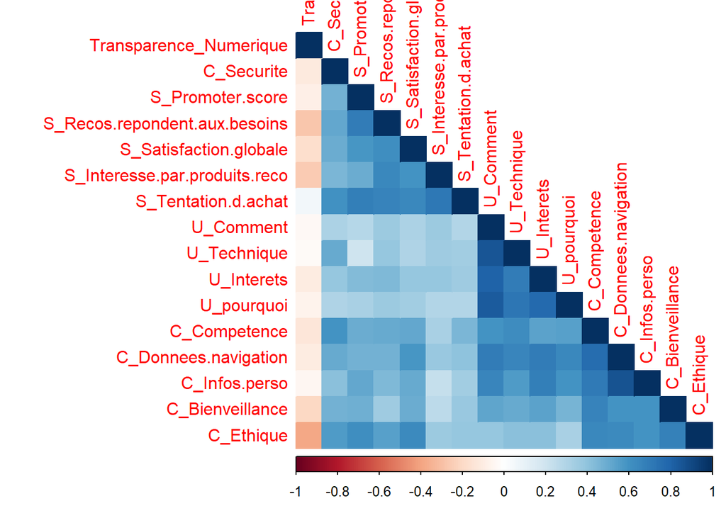

```r
corrplot(M, method="color",type="lower", order="hclust")
```

## Factor analysis and measurement reliability

done with Rcmdr (factanal) with 3 factors and a promax rotation that let the factor to be correlated.

more is here http://www.karlin.mff.cuni.cz/~maciak/NMST539/cvicenie8.html

or http://www.di.fc.ul.pt/~jpn/r/factoranalysis/factoranalysis.html

to do better use the package psych :

```r
.FA <- factanal(~C_Bienveillance+C_Competence+C_Donnees.navigation+C_Ethique+C_Infos.perso+C_Securite+S_Interesse.par.produits.reco+S_Promoter.score+S_Recos.repondent.aux.besoins+S_Satisfaction.globale+S_Tentation.d.achat+U_Comment+U_Interets+U_pourquoi+U_Technique,factors=3, rotation="promax", scores="none", data=reco_a)
print(.FA)
```

```
##
## Call:
## factanal(x = ~C_Bienveillance + C_Competence + C_Donnees.navigation +     C_Ethique + C_Infos.perso + C_Securite + S_Interesse.par.produits.reco +     S_Promoter.score + S_Recos.repondent.aux.besoins + S_Satisfaction.globale +     S_Tentation.d.achat + U_Comment + U_Interets + U_pourquoi +     U_…
##
## Uniquenesses:
##               C_Bienveillance                  C_Competence
##                         0.490                         0.317
##          C_Donnees.navigation                     C_Ethique
##                         0.154                         0.385
##                 C_Infos.perso                    C_Securite
##                         0.174                         0.521
## S_Interesse.par.produits.reco              S_Promoter.score
##                         0.307                         0.369
## S_Recos.repondent.aux.besoins        S_Satisfaction.globale
##                         0.352                         0.358
##           S_Tentation.d.achat                     U_Comment
##                         0.226                         0.048
##                    U_Interets                    U_pourquoi
##                         0.285                         0.277
##                   U_Technique
##                         0.245
##
## Loadings:
##                               Factor1 Factor2 Factor3
## C_Bienveillance                0.614           0.137
## C_Competence                   0.704           0.157
## C_Donnees.navigation           0.823  -0.101   0.239
## C_Ethique                      0.765   0.130  -0.142
## C_Infos.perso                  0.932  -0.236   0.180
## C_Securite                     0.310   0.464
## S_Interesse.par.produits.reco -0.388   0.973   0.216
## S_Promoter.score               0.360   0.580  -0.174
## S_Recos.repondent.aux.besoins          0.736
## S_Satisfaction.globale         0.401   0.541  -0.143
## S_Tentation.d.achat           -0.136   0.962
## U_Comment                                      0.945
## U_Interets                     0.224           0.655
## U_pourquoi                     0.103           0.776
## U_Technique                                    0.791
##
##                Factor1 Factor2 Factor3
## SS loadings      3.633   3.357   2.803
## Proportion Var   0.242   0.224   0.187
## Cumulative Var   0.242   0.466   0.653
##
## Factor Correlations:
##         Factor1 Factor2 Factor3
## Factor1   1.000  -0.364   0.585
## Factor2  -0.364   1.000  -0.671
## Factor3   0.585  -0.671   1.000
##
## Test of the hypothesis that 3 factors are sufficient.
## The chi square statistic is 81.51 on 63 degrees of freedom.
## The p-value is 0.0584
```

as we obtain a confirmation of the 3-dimensionnal structure of the response (Understanding,Trust, satisfaction) we could evaluate the reliability and validity of the scales computing conbach alpha and analysing between and inter scale correlations.

A Sem model is better of course ( see the last part) to test a Confirmatory Factor Analysis

for the case of Confiance( trust) alpha is excellen( (more than 0.90)). If the security item is eliminated, there is no loss of information. We could so reduce the scale without decreae its reliability.

```r
reliability(cov(reco_a[,c("C_Bienveillance","C_Competence","C_Donnees.navigation","C_Ethique",
  "C_Infos.perso","C_Securite")], use="complete.obs"))
```

```
## Alpha reliability =  0.9005
## Standardized alpha =  0.9058
##
## Reliability deleting each item in turn:
##                       Alpha Std.Alpha r(item, total)
## C_Bienveillance      0.8866    0.8929         0.7053
## C_Competence         0.8740    0.8773         0.8218
## C_Donnees.navigation 0.8678    0.8774         0.8235
## C_Ethique            0.8835    0.8885         0.7428
## C_Infos.perso        0.8775    0.8858         0.7678
## C_Securite           0.9057    0.9104         0.5801
```

```r
M<-subset(reco_a, select=c("Confiance", "Understanding", "Satisfaction"))
M<-round(cor(M),2)
M
```

```
##               Confiance Understanding Satisfaction
## Confiance          1.00          0.71         0.60
## Understanding      0.71          1.00         0.43
## Satisfaction       0.60          0.43         1.00
```

## model testing

for a quick but complete presentation http://www.sthda.com/english/articles/40-regression-analysis/168-multiple-linear-regression-in-r/

```r
LinearModel.2 <- lm(Confiance ~ Sexe + Transparence_Nominale, data=reco_a)
summary(LinearModel.2)
```

```
##
## Call:
## lm(formula = Confiance ~ Sexe + Transparence_Nominale, data = reco_a)
##
## Residuals:
##      Min       1Q   Median       3Q      Max
## -1.56883 -0.58208  0.06084  0.48776  1.37818
##
## Coefficients:
##                                Estimate Std. Error t value Pr(>|t|)
## (Intercept)                      3.8218     0.2064  18.514   <2e-16 ***
## SexeMasculin                    -0.2530     0.2161  -1.171   0.2475
## Transparence_Nominale2-Moderee   0.4877     0.2598   1.877   0.0666 .
## Transparence_Nominale3-Forte    -0.2910     0.2637  -1.103   0.2754
## ---
## Signif. codes:  0 '***' 0.001 '**' 0.01 '*' 0.05 '.' 0.1 ' ' 1
##
## Residual standard error: 0.768 on 48 degrees of freedom
## Multiple R-squared:  0.1872, Adjusted R-squared:  0.1364
## F-statistic: 3.685 on 3 and 48 DF,  p-value: 0.01814
```

```r
LinearModel.3 <- lm(Confiance ~ Sexe + Transparence_Nominale +Transparence_Nominale*Sexe, data=reco_a)
summary(LinearModel.3)
```

```
##
## Call:
## lm(formula = Confiance ~ Sexe + Transparence_Nominale + Transparence_Nominale *
##     Sexe, data = reco_a)
##
## Residuals:
##      Min       1Q   Median       3Q      Max
## -1.54286 -0.56714  0.08312  0.47857  1.36000
##
## Coefficients:
##                                             Estimate Std. Error t value
## (Intercept)                                  3.84000    0.24801  15.483
## SexeMasculin                                -0.29714    0.38649  -0.769
## Transparence_Nominale2-Moderee               0.45091    0.34267   1.316
## Transparence_Nominale3-Forte                -0.30667    0.36035  -0.851
## SexeMasculin:Transparence_Nominale2-Moderee  0.09195    0.54145   0.170
## SexeMasculin:Transparence_Nominale3-Forte    0.03881    0.54278   0.072
##                                             Pr(>|t|)
## (Intercept)                                   <2e-16 ***
## SexeMasculin                                   0.446
## Transparence_Nominale2-Moderee                 0.195
## Transparence_Nominale3-Forte                   0.399
## SexeMasculin:Transparence_Nominale2-Moderee    0.866
## SexeMasculin:Transparence_Nominale3-Forte      0.943
## ---
## Signif. codes:  0 '***' 0.001 '**' 0.01 '*' 0.05 '.' 0.1 ' ' 1
##
## Residual standard error: 0.7843 on 46 degrees of freedom
## Multiple R-squared:  0.1877, Adjusted R-squared:  0.09944
## F-statistic: 2.126 on 5 and 46 DF,  p-value: 0.07909
```

```r
anova(LinearModel.2,LinearModel.3)
```

```
## Analysis of Variance Table
##
## Model 1: Confiance ~ Sexe + Transparence_Nominale
## Model 2: Confiance ~ Sexe + Transparence_Nominale + Transparence_Nominale *
##     Sexe
##   Res.Df    RSS Df Sum of Sq      F Pr(>F)
## 1     48 28.312
## 2     46 28.294  2   0.01792 0.0146 0.9855
```

```r
#for illustration
level<- aggregate(cbind(Confiance, Satisfaction, Understanding) ~ Transparence_Nominale+Sexe, data=reco_a, FUN="mean")
level <- melt(level)
```

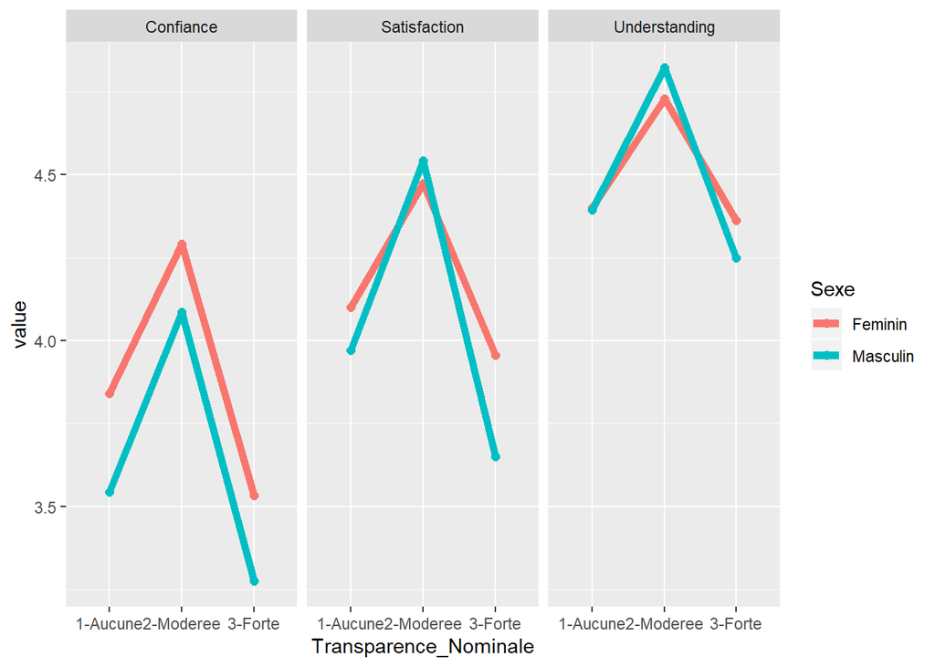

```r
p1 <- ggplot(data = level, aes(x = Transparence_Nominale, y = value, group =Sexe, color=Sexe ))
p1<- p1 + geom_point(size=2)+geom_line(stat="identity", size=2)+facet_grid(.~variable)
p1
```

to improve the procedure, a classic aproach is “Process” implemented in the processr package : https://rpubs.com/markhw/processr.

It is usefull ( nd it is a growing trend) to represent graphically the results of a regression model. Jtools is usefull for this purpose with the Plot_summs function. See :

```r
summ(LinearModel.3)
```

| Observations | 52 |
| --- | --- |
| Dependent variable | Confiance |
| Type | OLS linear regression |

| F(5,46) | 2.13 |
| --- | --- |
| R² | 0.19 |
| Adj. R² | 0.10 |

|  | Est. | S.E. | t val. | p |
| --- | --- | --- | --- | --- |
| (Intercept) | 3.84 | 0.25 | 15.48 | 0.00 |
| SexeMasculin | -0.30 | 0.39 | -0.77 | 0.45 |
| Transparence_Nominale2-Moderee | 0.45 | 0.34 | 1.32 | 0.19 |
| Transparence_Nominale3-Forte | -0.31 | 0.36 | -0.85 | 0.40 |
| SexeMasculin:Transparence_Nominale2-Moderee | 0.09 | 0.54 | 0.17 | 0.87 |
| SexeMasculin:Transparence_Nominale3-Forte | 0.04 | 0.54 | 0.07 | 0.94 |

Standard errors: OLS

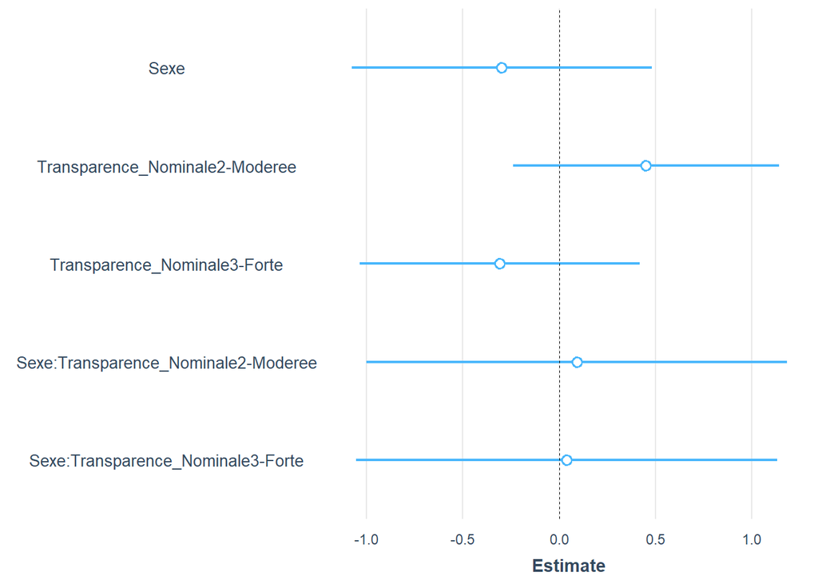

```r
plot_summs(LinearModel.3, scale = TRUE)
```

## Clustering

### kmeans

look at this bank customer segmentation exemple https://rpubs.com/cpatinof/clusteringMktngDataCaseStudy

[output not shown]

[figure not shown]

### hierarchical clustering

this method come from biology and was develop to classify species :

https://cran.r-project.org/web/packages/dendextend/vignettes/Cluster_Analysis.html

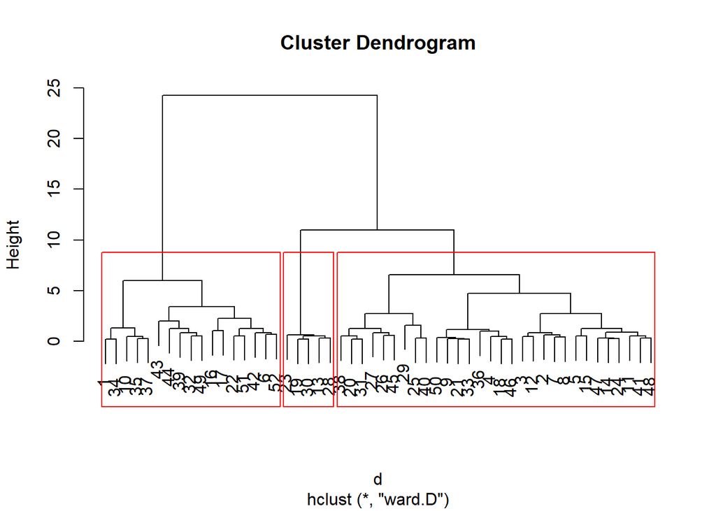

```r
# Ward Hierarchical Clustering
d <- dist(x, method = "euclidean") # distance matrix
fit <- hclust(d, method="ward.D")
plot(fit) # display dendogram
HCgroups <- cutree(fit, k=3) # cut tree into 5 clusters
# draw dendogram with red borders around the 5 clusters
rect.hclust(fit, k=3, border="red")
```

### Convergence test

do the two method give the same results?

just crosstabs and compute the chi² test.

```r
KMcluster<-as.data.frame(kmeans[[1]]) #extract a component from a list
names(KMcluster)[names(KMcluster)=="kmeans[[1]]"] <- "KMcluster"
typo<-cbind(KMcluster,HCgroups)
typo$KMcluster<-as.factor(typo$KMcluster)
typo$HCgroups<-as.factor(typo$HCgroups)

.Table <- xtabs(~HCgroups+KMcluster, data=typo)
  cat("\nFrequency table:\n")
```

```
##
## Frequency table:
```

```r
  print(.Table)
```

```
##         KMcluster
## HCgroups  1  2  3
##        1 17  0  0
##        2  0 27  3
##        3  0  0  5
```

```r
  .Test <- chisq.test(.Table, correct=FALSE)
  print(.Test)
```

```
##
##  Pearson's Chi-squared test
##
## data:  .Table
## X-squared = 81.25, df = 4, p-value < 2.2e-16
```

```r
  cat("\nExpected counts:\n")
```

```
##
## Expected counts:
```

```r
  print(.Test$expected)
```

```
##         KMcluster
## HCgroups        1         2         3
##        1 5.557692  8.826923 2.6153846
##        2 9.807692 15.576923 4.6153846
##        3 1.634615  2.596154 0.7692308
```

```r
  cat("\nChi-square components:\n")
```

```
##
## Chi-square components:
```

```r
  print(round(.Test$residuals^2, 2))
```

```
##         KMcluster
## HCgroups     1     2     3
##        1 23.56  8.83  2.62
##        2  9.81  8.38  0.57
##        3  1.63  2.60 23.27
```

# Structural equation modeling

we use Lavaan

http://lavaan.ugent.be/

```
## lavaan 0.6-5 ended normally after 42 iterations
##
##   Estimator                                         ML
##   Optimization method                           NLMINB
##   Number of free parameters                         33
##
##   Number of observations                            52
##
## Model Test User Model:
##
##   Test statistic                               173.278
##   Degrees of freedom                               102
##   P-value (Chi-square)                           0.000
##
## Parameter Estimates:
##
##   Information                                 Expected
##   Information saturated (h1) model          Structured
##   Standard errors                             Standard
##
## Latent Variables:
##                    Estimate  Std.Err  z-value  P(>|z|)   Std.lv  Std.all
##   Confiance =~
##     C_Bienveillanc    1.000                               0.667    0.689
##     C_Competence      0.941    0.171    5.510    0.000    0.628    0.823
##     C_Donnes.nvgtn    1.449    0.238    6.089    0.000    0.966    0.923
##     C_Ethique         0.815    0.172    4.725    0.000    0.543    0.697
##     C_Infos.perso     1.371    0.237    5.798    0.000    0.914    0.871
##   Satisfaction =~
##     S_Intrss.pr.p.    1.000                               0.608    0.745
##     S_Promoter.scr    1.009    0.181    5.587    0.000    0.613    0.781
##     S_Rcs.rpndnt..    1.165    0.198    5.883    0.000    0.708    0.820
##     S_Stsfctn.glbl    1.004    0.183    5.472    0.000    0.610    0.766
##     S_Tenttn.d.cht    1.462    0.243    6.016    0.000    0.888    0.838
##   Understanding =~
##     U_Comment         1.000                               1.011    0.962
##     U_Interets        0.691    0.071    9.745    0.000    0.698    0.842
##     U_pourquoi        0.773    0.075   10.353    0.000    0.781    0.861
##     U_Technique       0.936    0.089   10.541    0.000    0.946    0.866
##
```

[output cut: 17 more lines]

```
##    .C_Ethique         0.311    0.065    4.768    0.000    0.311    0.514
##    .C_Infos.perso     0.267    0.067    3.959    0.000    0.267    0.242
##    .S_Intrss.pr.p.    0.295    0.067    4.393    0.000    0.295    0.444
##    .S_Promoter.scr    0.241    0.057    4.214    0.000    0.241    0.391
##    .S_Rcs.rpndnt..    0.244    0.062    3.930    0.000    0.244    0.328
##    .S_Stsfctn.glbl    0.263    0.061    4.297    0.000    0.263    0.414
##    .S_Tenttn.d.cht    0.335    0.089    3.756    0.000    0.335    0.298
##    .U_Comment         0.083    0.040    2.106    0.035    0.083    0.075
##    .U_Interets        0.200    0.045    4.468    0.000    0.200    0.291
##    .U_pourquoi        0.213    0.049    4.343    0.000    0.213    0.259
##    .U_Technique       0.297    0.069    4.299    0.000    0.297    0.249
##    .Tr1               0.226    0.044    5.099    0.000    0.226    1.000
##    .Confiance         0.172    0.066    2.605    0.009    0.386    0.386
##    .Satisfaction      0.227    0.078    2.897    0.004    0.615    0.615
##     Understanding     1.021    0.219    4.664    0.000    1.000    1.000
```

```
## lavaan 0.6-5 ended normally after 109 iterations
##
##   Estimator                                         ML
##   Optimization method                           NLMINB
##   Number of free parameters                         96
##
##   Number of observations per group:
##     Masculin                                        22
##     Feminin                                         30
##
## Model Test User Model:
##
##   Test statistic                               351.125
##   Degrees of freedom                               204
##   P-value (Chi-square)                           0.000
##   Test statistic for each group:
##     Masculin                                   214.370
##     Feminin                                    136.756
##
## Parameter Estimates:
##
##   Information                                 Expected
##   Information saturated (h1) model          Structured
##   Standard errors                             Standard
##
##
## Group 1 [Masculin]:
##
## Latent Variables:
##                    Estimate  Std.Err  z-value  P(>|z|)   Std.lv  Std.all
##   Confiance =~
##     C_Bienveillanc    1.000                               0.565    0.616
##     C_Competence      1.035    0.340    3.043    0.002    0.585    0.800
##     C_Donnes.nvgtn    1.631    0.489    3.337    0.001    0.922    0.922
##     C_Ethique         0.778    0.326    2.384    0.017    0.440    0.581
##     C_Infos.perso     1.491    0.454    3.287    0.001    0.843    0.899
##   Satisfaction =~
##     S_Intrss.pr.p.    1.000                               0.595    0.755
##     S_Promoter.scr    0.953    0.248    3.838    0.000    0.567    0.808
##     S_Rcs.rpndnt..    1.114    0.278    4.002    0.000    0.663    0.841
```

[output cut: 123 more lines]

```
##    .C_Ethique         0.234    0.066    3.566    0.000    0.234    0.422
##    .C_Infos.perso     0.319    0.099    3.208    0.001    0.319    0.259
##    .S_Intrss.pr.p.    0.295    0.089    3.325    0.001    0.295    0.422
##    .S_Promoter.scr    0.312    0.092    3.376    0.001    0.312    0.445
##    .S_Rcs.rpndnt..    0.308    0.096    3.201    0.001    0.308    0.374
##    .S_Stsfctn.glbl    0.251    0.082    3.066    0.002    0.251    0.333
##    .S_Tenttn.d.cht    0.329    0.121    2.713    0.007    0.329    0.258
##    .U_Comment         0.078    0.054    1.455    0.146    0.078    0.086
##    .U_Interets        0.277    0.081    3.443    0.001    0.277    0.365
##    .U_pourquoi        0.225    0.070    3.209    0.001    0.225    0.283
##    .U_Technique       0.383    0.109    3.510    0.000    0.383    0.401
##    .Tr1               0.232    0.060    3.873    0.000    0.232    1.000
##    .Confiance         0.184    0.090    2.041    0.041    0.373    0.373
##    .Satisfaction      0.226    0.100    2.249    0.024    0.558    0.558
##     Understanding     0.829    0.238    3.475    0.001    1.000    1.000
```

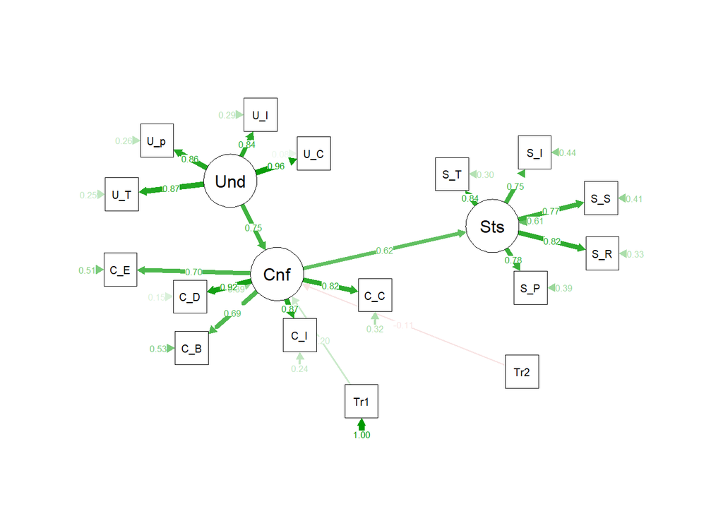